# GRAD-C6-2001: Statistics II — Replication Paper

Jeannet, Anne-Marie (2018). Revisiting the labor market

Kathryn Malchow, Github username: KathrynMalchow

June 01, 2021 | 14:52:05 | CEST

### Fact Sheet

This study evaluates the causal effect of retirement on attitudes towards immigration. The data used was taken from Round 7 (2014) of the European Social Survey of 14 Western European countries. The sample population was restricted to men aged between 50 and 69 years who have worked after the age of 50. The author, Anne-Marie Jeannet, states that self-selection into retirement would cause omitted variable bias due to the correlation between this choice and their opinions and values about immigration. To counter this issue, the study uses the early and full statutory retirement ages of each country as instrumental variables because they are a strong predictor of retirement and allegedly do not directly influence opinion on immigration. This model is illustrated through the directed acyclic graph below.

The study found that retirement is not a significant predictor of attitudes towards immigration. This does not support the labor market competition hypothesis that as people retire, they no longer have to compete with others for work, and therefore might change their opinions on immigration.

One issue I see with this model is that the exclusion restriction might be violated. It seems like statutory retirement ages would have a direct affect on attitudes. For instance, those living in countries with higher retirement ages would be more reluctant to share their country’s wealth if they will have to work longer into life.

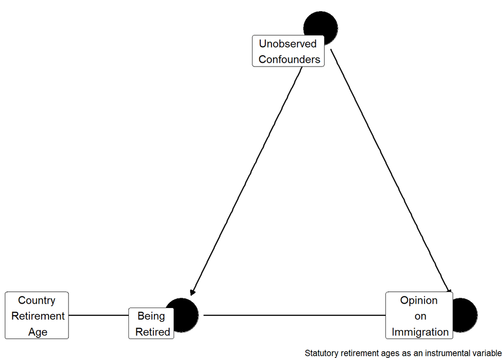

```r
#Set coordinates for dag nodes
DAGCoord<- list(
    x=c(Retirement_Age=1,Being_Retired=2,Unobserved_Confounders=3,Opinion_on_Immigration=4),
    y=c(Retirement_Age=0,Being_Retired=0,Unobserved_Confounders=3,Opinion_on_Immigration=0))

#Make DAG with new labels
DAG <- dagify(Being_Retired ~ Retirement_Age,
              Opinion_on_Immigration ~ Being_Retired,
              Opinion_on_Immigration ~ Unobserved_Confounders,
              Being_Retired ~ Unobserved_Confounders,
              coords = DAGCoord,
              labels = c("Being_Retired" = "Being\n Retired",
                                           "Retirement_Age" = "Country\n Retirement\n Age",
                                           "Opinion_on_Immigration" = "Opinion\n on\n Immigration",
                                           "Unobserved_Confounders" = "Unobserved\n Confounders"))
#Show DAG
ggdag(DAG,
      text = FALSE, # hide original names
      use_labels = "label") + # for new names
      theme_void()+
      labs(caption = "Statutory retirement ages as an instrumental variable")
```

### Figure 1

Figure 1 is a faceted graph showing that there is no discontinuity in attitudes towards immigration at the full retirement ages of each country. This is to prove that the exclusion restriction assumption holds.

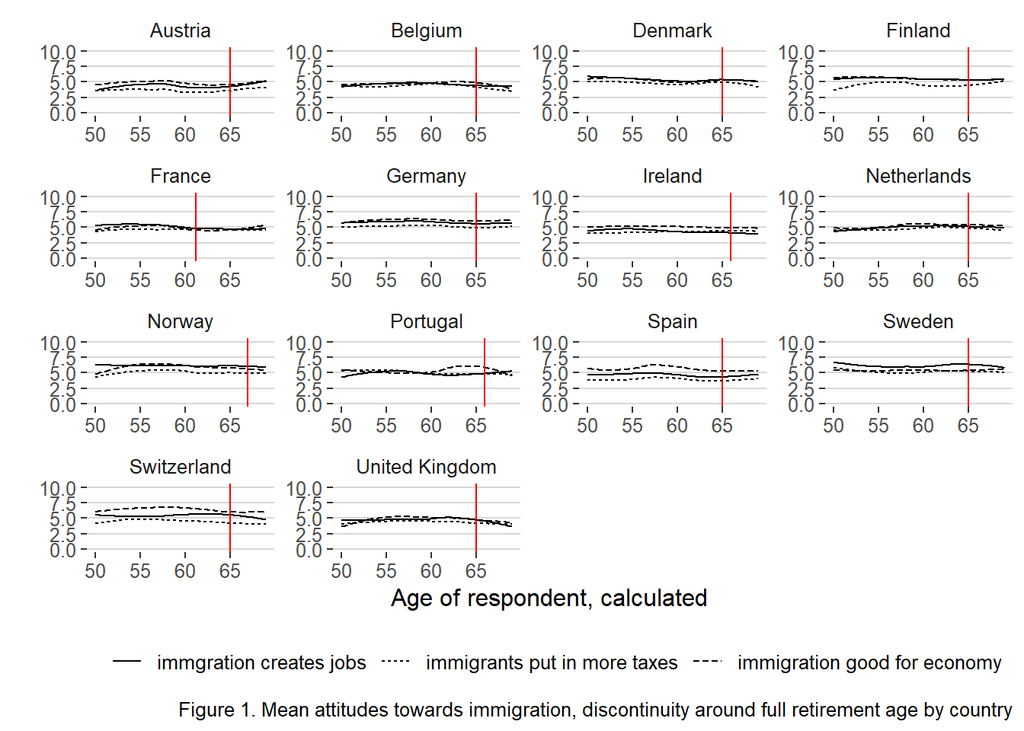

```r
#df for figure 1
Fig_1 <- data[,c("imbgeco","imbleco","imtcjob", "agea", "full_retire_age", "cntry")]

# changing to long data-frame
long_df <- Fig_1 %>%
  pivot_longer(
  cols = c(imbgeco, imbleco, imtcjob),
  names_to = "Question",
  values_to = "Rating" )

#changing the country labels to match original
long_df$cntry[long_df$cntry == "AT"] <- "Austria"
long_df$cntry[long_df$cntry == "BE"] <- "Belgium"
long_df$cntry[long_df$cntry == "DK"] <- "Denmark"
long_df$cntry[long_df$cntry == "FI"] <- "Finland"
long_df$cntry[long_df$cntry == "FR"] <- "France"
long_df$cntry[long_df$cntry == "DE"] <- "Germany"
long_df$cntry[long_df$cntry == "IE"] <- "Ireland"
long_df$cntry[long_df$cntry == "NL"] <- "Netherlands"
long_df$cntry[long_df$cntry == "PT"] <- "Portugal"
long_df$cntry[long_df$cntry == "ES"] <- "Spain"
long_df$cntry[long_df$cntry == "SE"] <- "Sweden"
long_df$cntry[long_df$cntry == "GB"] <- "United Kingdom"
long_df$cntry[long_df$cntry == "CH"] <- "Switzerland"
long_df$cntry[long_df$cntry == "NO"] <- "Norway"

#rename questions
long_df$Question[long_df$Question == "imbgeco"] <- "immigration good for economy"
long_df$Question[long_df$Question == "imtcjob"] <- "immgration creates jobs"
long_df$Question[long_df$Question == "imbleco"] <- "immigrants put in more taxes"

#plot graph
fig_1_graph <- long_df %>%
  ggplot(aes(x = agea,y = Rating, linetype = Question)) +
  facet_wrap(vars(cntry), scales = "free", ncol = 4) +
  theme(strip.background = element_blank()) + #remove grey box from country label
  geom_smooth(se=F, colour="black", size= 0.5) + # remove confidence interval
  geom_vline(data = long_df, mapping = aes(xintercept = full_retire_age), color = "red") +
  labs(x = "Age of respondent, calculated",
       y = "",
       caption = "Figure 1. Mean attitudes towards immigration, discontinuity around full retirement age by country") +
  theme_hc() +
  ylim(0,10) +
  theme(legend.title=element_blank())


fig_1_graph
```

My results look a little different than the original. This might be because the numbers on the left side are scaled by 2.5 instead of 2, but I could not get scaling by increments of 2 to work. It still shows that there is no discontinuity for any of the 3 questions at full retirement ages in each country.

### Table 2 as a Figure

Table 2 shows the percentages of those retired out of the sample population per country, the percentage of the entire sample that are older than the early retirement age of each country, and the percentage of the entire sample that are older than the full retirement age of each country. These rates were used to show that the instruments, early and full retirement ages, have relevancy, meaning they have an influence on the likelihood someone is retired.

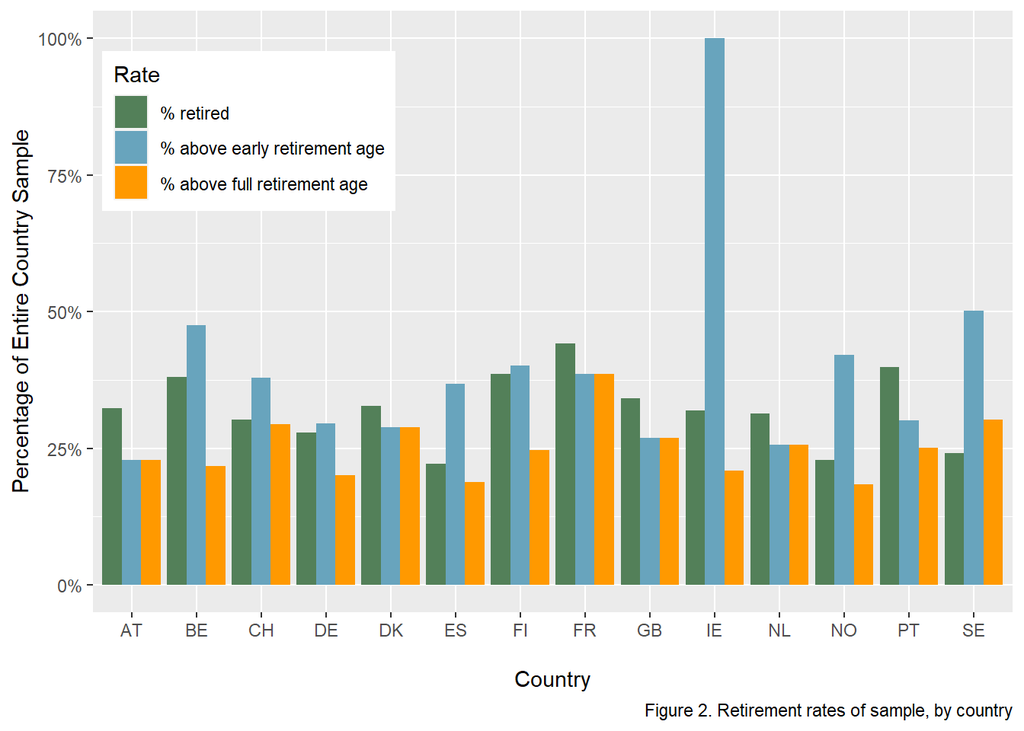

```r
#df for this table
table2_df <- data[, c("cntry", "above_early", "above_full", "rtrd")]


#creating new data tables with percentages
dt_1 <- setDT(table2_df)[,.(.N,perc_early=sum(above_early==1)/.N),
         by=cntry]
dt_2 <- setDT(table2_df)[,.(.N,perc_full=sum(above_full==1)/.N),
         by=cntry]
dt_3 <- setDT(table2_df)[,.(.N,perc_retired=sum(rtrd==1)/.N),
         by=cntry]

merge_1 <- merge(x = dt_1, y = dt_2, by = "cntry", all.x = TRUE) # can only merge 2 data tables at a time
merge_final <- merge(x = merge_1, y = dt_3, by = "cntry", all.x = TRUE) #merge all together

#changing to long data-frame
long_merge_final <- merge_final %>%
  pivot_longer(
  cols = c(perc_retired, perc_early, perc_full),
  names_to = "Rate",
  values_to = "Percentage" )

#reorder rates
long_merge_final$Rate <- factor(long_merge_final$Rate,levels = c("perc_retired","perc_early","perc_full"))

#plot graph
ggplot(long_merge_final, aes(x = cntry,
                         y= Percentage,
                         fill = Rate)) +
  geom_bar(stat = "identity", position = "dodge")+
  scale_y_continuous(labels = percent)+
  labs(x = "\nCountry",
       y = "Percentage of Entire Country Sample",
       fill = "Rate",
       caption = "Figure 2. Retirement rates of sample, by country")+
theme(legend.position = c(0.17, 0.8))+
  scale_fill_manual(limits = c("perc_retired", "perc_early", "perc_full"),
                      labels = c("% retired", "% above early retirement age", "% above full retirement age"),
                      values = c("perc_retired" = "#538059",
                               "perc_early" = "#68a4bd",
                               "perc_full" = "#ff9900"))
```

As a table, the percentages were very confusing. It was not clear if the above early and full retirement ages were percentages of the percent retired, or percentages of the entire population per country. I used a bar chart with more descriptive labels to try and make this clear. Ireland’s bar reaches 100 percent for the amount of those above early retirement age because their early retirement age is 50 and the data is restricted to those aged 50-69. While this chart makes the data more accessible to look at, the idea that early and full retirement ages predict a person’s tendency to retire is still not clear from the data.

### Table 3

```r
#new df so I can change the names easier
df_table3 <- data[,c("imbgeco","imbleco","imtcjob", "agea", "full_retire_age", "cntry", "above_early", "above_full", "early_retire_age", "eduyrs", "hinctnta", "lrscale", "brncntr", "rural", "agesquared", "ever_child", "married", "rtrd","iscoco10", "country")]


#changing names to match original table 3
df_table3 <- setNames(df_table3,  c("Economy","Taxes_and_Services","Jobs", "Age", "full_retire_age","cntry", "Above_early", "Above_full", "early_retire_age", "Education", "Income", "Left_right", "Born_abroad", "Rural", "Age_squared", "Children", "Married", "Being_retired", "iscoco10", "country"))


#run regression
lm(Being_retired ~ Above_early + Above_full + Age + Age_squared + Education + Income + Children + Left_right + Born_abroad + factor(Married) + factor(Rural) + factor(iscoco10) + factor(country), data = df_table3) %>%
stargazer(type = "text",
omit = c("country", "iscoco10"),  #hide country and occupational dummy variables
title="Table 3. First stage results")
```

```
##
## Table 3. First stage results
## ===============================================
##                         Dependent variable:
##                     ---------------------------
##                            Being_retired
## -----------------------------------------------
## Above_early                  0.136***
##                               (0.021)
##
## Above_full                   0.187***
##                               (0.026)
##
## Age                          -0.177***
##                               (0.028)
##
## Age_squared                  0.002***
##                              (0.0002)
##
## Education                     -0.003*
##                               (0.002)
##
## Income                       -0.011***
##                               (0.002)
##
## Children                       0.001
##                               (0.014)
##
## Left_right                     0.001
##                               (0.002)
##
## Born_abroad                  -0.066***
##                               (0.019)
##
## factor(Married)1             0.035***
##                               (0.012)
##
## factor(Rural)1                0.026**
##                               (0.011)
##
## Constant                     4.562***
##                               (0.806)
##
## -----------------------------------------------
## Observations                   3,655
## R2                             0.573
## Adjusted R2                    0.569
## Residual Std. Error      0.308 (df = 3622)
## F Statistic         151.679*** (df = 32; 3622)
## ===============================================
## Note:               *p<0.1; **p<0.05; ***p<0.01
```

My results are pretty close to the original. There are differences of between 0.001 and 0.003 in some of the coefficients. The differences between my standard errors and the original are bigger. For instance, my above_early result has 0.021 and the original has 0.028. For above_full, I got 0.026 while the original has 0.034. These differences might be due to the different amount of observations between the two models. The author has 3,616 observations while I have 3,655. I tried omitting NAs to get closer to 3,616, but this caused the observations to be less than 3,616.

### Table 4

Table 4 shows the results from ordinary least squares and instrumental variable models for each question on attitudes towards immigration. These questions are is immigration good for the economy, does immigration create more jobs, and do immigrants contribute more in taxes than what they use in services. The results show that retirement has a negative effect on all of the opinions, but insignificantly.

```r
#new df to rename
table4_df <- data[,c("imbgeco","imbleco","imtcjob", "agea", "full_retire_age", "cntry", "above_early", "above_full", "early_retire_age", "eduyrs", "hinctnta", "lrscale", "brncntr", "rural", "agesquared", "ever_child", "married", "rtrd","iscoco10", "country")]

#rename to match original table
table4_df <- setNames(table4_df,  c("Economy","Taxes_and_Services","Jobs", "Age", "full_retire_age","cntry", "Above_early", "Above_full", "early_retire_age", "Education", "Income", "Left_right", "Born_abroad", "Rural", "Age_squared", "Children", "Married", "Retired", "iscoco10", "country"))


#OLS
OLS_Eco <- lm_robust(Economy ~ Retired + Age + Age_squared + Education + Income + Children + Left_right + Born_abroad + factor(Married) + factor(Rural) + factor(iscoco10) + factor(country), data = table4_df)

OLS_Jobs <- lm_robust(Jobs ~ Retired + Age + Age_squared + Education + Income + Children + Left_right + Born_abroad + factor(Married) + factor(Rural) + factor(iscoco10) + factor(country), data = table4_df)

OLS_Taxes_Services <- lm_robust(Taxes_and_Services ~ Retired + Age + Age_squared + Education + Income + Children + Left_right + Born_abroad + factor(Married) + factor(Rural) + factor(iscoco10) + factor(country), data = table4_df)

#IV
IV_Eco <- iv_robust(Economy ~ Retired + Age + Age_squared + Education + Income + Children + Left_right + Born_abroad + factor(Married) + factor(Rural) + factor(iscoco10) + factor(country) | Age + Age_squared + Education + Income + Children + Left_right + Born_abroad + factor(Married) + factor(Rural) + factor(iscoco10) + factor(country) + Above_early + Above_full, data = table4_df)

IV_Jobs <- iv_robust(Jobs ~ Retired + Age + Age_squared + Education + Income + Children + Left_right + Born_abroad + factor(Married) + factor(Rural) + factor(iscoco10) + factor(country) | Age + Age_squared + Education + Income + Children + Left_right + Born_abroad + factor(Married) + factor(Rural) + factor(iscoco10) + factor(country) + Above_early + Above_full, data = table4_df)

IV_Taxes_Services <- iv_robust(Taxes_and_Services ~ Retired + Age + Age_squared + Education + Income + Children + Left_right + Born_abroad + factor(Married) + factor(Rural) + factor(iscoco10) + factor(country) | Age + Age_squared + Education + Income + Children + Left_right + Born_abroad + factor(Married) + factor(Rural) + factor(iscoco10) + factor(country)+ Above_early + Above_full, data = table4_df)


#plot table
table4 <- tab_model(OLS_Eco , IV_Eco , OLS_Jobs , IV_Jobs , OLS_Taxes_Services , IV_Taxes_Services,
                    auto.label = FALSE, show.ci = FALSE, show.p = FALSE, show.se = TRUE,  #show standard errors
                    dv.labels = c("Economy-OLS", "Economy-IV", "Jobs-OLS", "Jobs-IV", "Taxes and Services-OLS",                        "Taxes and Services-IV"), #name variables
                    rm.terms = "factor(country) [2,3,5,6,8,9,10,11,13,16,17,19,20]", #hide country factors
                    title = "Table 4. Ordinary least squares (OLS) and instrumental variable (IV) results",
                    file = "t4.html")

#view table
includeHTML("t4.html")
```

Table 4. Ordinary least squares (OLS) and instrumental variable (IV) results

|  | Economy-OLS |  | Economy-IV |  | Jobs-OLS |  | Jobs-IV |  | Taxes and Services-OLS |  | Taxes and Services-IV |  |
| --- | --- | --- | --- | --- | --- | --- | --- | --- | --- | --- | --- | --- |
| Predictors | Estimates | std. Error | Estimates | std. Error | Estimates | std. Error | Estimates | std. Error | Estimates | std. Error | Estimates | std. Error |
| (Intercept) | -5.10 | 4.53 | 0.09 | 7.76 | -0.28 | 4.19 | 3.08 | 7.49 | -2.37 | 4.37 | 0.89 | 7.68 |
| Retired | -0.09 | 0.12 | -0.60 | 0.64 | -0.01 | 0.12 | -0.35 | 0.63 | -0.02 | 0.12 | -0.35 | 0.64 |
| Age | 0.31 | 0.15 | 0.11 | 0.28 | 0.13 | 0.14 | 0.00 | 0.27 | 0.19 | 0.15 | 0.07 | 0.28 |
| Age_squared | -0.00 | 0.00 | -0.00 | 0.00 | -0.00 | 0.00 | 0.00 | 0.00 | -0.00 | 0.00 | -0.00 | 0.00 |
| Education | 0.07 | 0.01 | 0.07 | 0.01 | 0.05 | 0.01 | 0.05 | 0.01 | 0.04 | 0.01 | 0.04 | 0.01 |
| Income | 0.07 | 0.02 | 0.07 | 0.02 | 0.04 | 0.02 | 0.03 | 0.02 | 0.03 | 0.02 | 0.03 | 0.02 |
| Children | -0.08 | 0.10 | -0.08 | 0.10 | 0.01 | 0.10 | 0.01 | 0.10 | -0.22 | 0.10 | -0.22 | 0.10 |
| Left_right | -0.14 | 0.02 | -0.13 | 0.02 | -0.04 | 0.02 | -0.04 | 0.02 | -0.15 | 0.02 | -0.15 | 0.02 |
| Born_abroad | 0.67 | 0.15 | 0.64 | 0.16 | 0.60 | 0.14 | 0.58 | 0.15 | 0.79 | 0.14 | 0.76 | 0.15 |
| factor(Married)1 | -0.04 | 0.09 | -0.02 | 0.09 | -0.04 | 0.08 | -0.02 | 0.08 | 0.11 | 0.09 | 0.12 | 0.09 |
| factor(Rural)1 | -0.16 | 0.08 | -0.15 | 0.08 | -0.13 | 0.07 | -0.12 | 0.07 | 0.02 | 0.07 | 0.03 | 0.08 |
| factor(iscoco10)2 | -0.07 | 0.13 | -0.07 | 0.13 | -0.08 | 0.11 | -0.08 | 0.11 | -0.01 | 0.13 | -0.01 | 0.13 |
| factor(iscoco10)3 | -0.30 | 0.13 | -0.30 | 0.13 | -0.23 | 0.12 | -0.23 | 0.12 | -0.38 | 0.13 | -0.38 | 0.13 |
| factor(iscoco10)4 | -0.47 | 0.19 | -0.46 | 0.19 | -0.18 | 0.16 | -0.18 | 0.16 | -0.18 | 0.18 | -0.17 | 0.18 |
| factor(iscoco10)5 | -0.87 | 0.18 | -0.88 | 0.18 | -0.62 | 0.16 | -0.63 | 0.16 | -0.45 | 0.17 | -0.45 | 0.17 |
| factor(iscoco10)6 | -0.94 | 0.21 | -1.01 | 0.23 | -0.73 | 0.22 | -0.78 | 0.24 | -0.73 | 0.22 | -0.78 | 0.24 |
| factor(iscoco10)7 | -1.00 | 0.14 | -1.01 | 0.14 | -0.69 | 0.13 | -0.70 | 0.13 | -0.64 | 0.14 | -0.64 | 0.14 |
| factor(iscoco10)8 | -1.26 | 0.17 | -1.26 | 0.17 | -0.76 | 0.15 | -0.75 | 0.15 | -0.62 | 0.16 | -0.61 | 0.16 |
| factor(iscoco10)9 | -0.93 | 0.20 | -0.97 | 0.20 | -0.80 | 0.19 | -0.82 | 0.19 | -0.60 | 0.19 | -0.63 | 0.19 |
| Observations | 3616 |  | 3616 |  | 3607 |  | 3607 |  | 3598 |  | 3598 |  |
| R<sup>2</sup> / R<sup>2</sup> adjusted | NA |  | 0.158 / 0.150 |  | NA |  | 0.125 / 0.118 |  | NA |  | 0.096 / 0.088 |  |

My results are very similar and are rounded in the thousandths digit. For these regressions, the number of observations are the same as the author’s as well. One issue I faced when producing the table is that I could not hide both the country and iscoco10 factors like the author did. I found out this might be a bug with the sjPlot package, so only the country factors are hidden in my table.

### Figure 2

Retirement proved insignificant in effecting opinions on immigration, which means that ideas about self-interests aren’t a main determinant of the subjects’ attitudes towards immigration. Other interests, such as one’s national economy, may have a bigger influence on attitudes.

Figure 2 displays the results from an experiment conducted within the ESS in which a sub sample of the survey was asked how many immigrants their country should let in. A control group was asked how many professionals from another country should be allowed to move in and a treatment group was asked how many unskilled laborers should be allowed to move in. The author used this experiment to determine if individuals base their opinions on what is best for their country’s economy, with the idea that professional level immigrants would create more benefit than burden for their country.

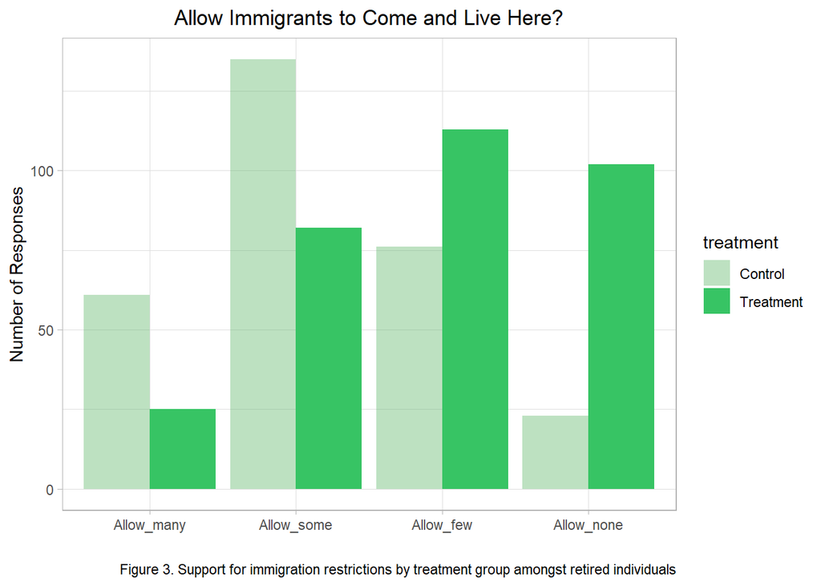

```r
#gather relevant variables
figure2_df <-data[,c("entry_allow", "treatment", "rtrd")]

#omitted NAs here so they wouldn't be graphed
figure2_df <- na.omit(figure2_df)

#select only retirees
figure2_df <- figure2_df %>%
  filter(rtrd == 1)


#must rename treatment/control for graph to work
figure2_df$treatment[figure2_df$treatment == 1] <- "Control"
figure2_df$treatment[figure2_df$treatment == 2] <- "Treatment"

#make new data frames
fg_2.1 <- setDT(figure2_df)[,.(Allow_many=sum(entry_allow==1)),
         by=treatment]
fg_2.2 <- setDT(figure2_df)[,.(Allow_some=sum(entry_allow==2)),
         by=treatment]
fg_2.3 <- setDT(figure2_df)[,.(Allow_few=sum(entry_allow==3)),
         by=treatment]
fg_2.4 <- setDT(figure2_df)[,.(Allow_none=sum(entry_allow==4)),
         by=treatment]

#merging data frames
merge1 <- merge(x = fg_2.1, y = fg_2.2, by = "treatment", all.x = TRUE)
merge2 <- merge(x = fg_2.3, y = fg_2.4, by = "treatment", all.x = TRUE)
merge3 <- merge(x = merge1, y = merge2, by = "treatment", all.x = TRUE)

#make long data frame
fg2_long <- merge3 %>%
  pivot_longer(
  cols = c(Allow_many, Allow_some, Allow_few, Allow_none),
  names_to = "Rating",
  values_to = "Number" )


#plot graph
ggplot(fg2_long, aes(x = Rating,
                         y= Number,
                         fill = treatment,
                         alpha = treatment,)) +
  geom_bar(stat = "identity",
           position = "dodge")+
  scale_x_discrete(limits = c("Allow_many",
                              "Allow_some",
                              "Allow_few",
                              "Allow_none"))+
  labs(x = "",
       y = "Number of Responses",
       fill = "treatment",
       caption = " Figure 3. Support for immigration restrictions by treatment group amongst retired individuals")+
  scale_fill_manual(values = c("Treatment" = "#37c464", "Control" = "#59b365"))+
  theme_light()+
  ggtitle("Allow Immigrants to Come and Live Here?") +
  theme(plot.title = element_text(hjust = 0.5))+
  scale_alpha_discrete(range=c(0.4, 1.0))
```

To make comparisons of interest easier to digest, I replicated the bar chart but put the control and treatment results side by side for each selection. This way, you can see the difference between the two easier. I also used number of responses for measurement instead of percentages because I think it is more intuitive.

##### Discrepancies

I first replicated this chart without limiting the subjects to retirees, and this gave me the same number of responses as the author, which was 1995. The author specifies though, that the results are amongst retired individuals. The current bar chart is limited to retirees, but has only 617 responses. Both bar charts, with or without being limited to retirees, depict the same thing; the treatment group favors stronger restrictions on immigration than the control group.

Another issue was that the treatment groups were not split completely evenly in either chart. With only retirees, control has 295 responses and treatment has 322. Even without a difference of 27 responses between the two groups there would be a clear distinction, which is why I still used numbers instead of percentages.

### Extension

A similar study conducted by Aaron Ponce evaluates how gender affects anti-immigration attitudes. The results show that there is no significant difference in general, but women are more likely to have lower opinions towards those from cultures with less gender equality. I thought this clash between liberal views on immigration and gender equality was an interesting interaction. I decided to run the models from “Revisiting the labor market” but using female subjects instead of men. I wanted to see if views on immigration would change with retirement for women or if no significant difference would be found between genders either.

To create a new data frame, I downloaded the original survey from the ESS website. I found some of the relevant variables within the original data, but realized that Jeannet had created some of her own. Some of the variables that I think she created were rural, married, country, ever_child, and iscoco10. Since I didn’t know how she went about creating these, I decided to leave them out of my model since rtrd (retired) was the important treatment variable. I created new columns for the instrumental variables above_early and above_full.

```r
#loaded original dataset
data2 <- read_stata("C:/Users/Kathryn/Downloads/ESS7e02_2.stata.zip")

#took relevant variables
extension_df <- data2[,c("imbgeco","imbleco","imtcjob", "agea", "cntry", "eduyrs", "hinctnta", "lrscale", "brncntr", "gndr", "rtrd")]

#omitted NAs
extension_df <- na.omit(extension_df)

#restricting to females aged 50-69
extension_df <- extension_df %>%
  filter( between(agea, 50, 69)) %>%
  filter(gndr == 2)

#restricting to the previously used 14 countries
extension_df <- subset(extension_df, cntry %in% c("AT", "BE", "DK", "FI", "FR", "DE", "IE", "NL", "PT", "ES", "SE", "GB", "CH", "NO"))

#rename variables
extension_df <- setNames(extension_df,  c("Economy","Taxes_and_Services","Jobs", "Age", "cntry", "Education", "Income", "Left_right", "Born_abroad", "gndr", "Retired"))


#add early and full retirement ages per country
extension_df <- extension_df %>%
  mutate(early_retire_age = case_when(
    (cntry == "AT") ~ 64.25,
    (cntry == "BE") ~ 60,
    (cntry == "DK") ~ 65,
    (cntry == "FI") ~ 63,
    (cntry == "FR") ~ 61.2,
    (cntry == "DE") ~ 63,
    (cntry == "IE") ~ 50,
    (cntry == "NL") ~ 65,
    (cntry == "PT") ~ 65,
    (cntry == "ES") ~ 61,
    (cntry == "SE") ~ 61,
    (cntry == "GB") ~ 65,
    (cntry == "CH") ~ 63,
    (cntry == "NO") ~ 62),
  full_retire_age = case_when(
    (cntry == "AT") ~ 65,
    (cntry == "BE") ~ 65,
    (cntry == "DK") ~ 65,
    (cntry == "FI") ~ 65,
    (cntry == "FR") ~ 61.2,
    (cntry == "DE") ~ 65,
    (cntry == "IE") ~ 66,
    (cntry == "NL") ~ 65,
    (cntry == "PT") ~ 66,
    (cntry == "ES") ~ 65,
    (cntry == "SE") ~ 65,
    (cntry == "GB") ~ 65,
    (cntry == "CH") ~ 65,
    (cntry == "NO") ~ 67))

#add above early and above full variables
extension_df <- extension_df %>%
  mutate(above_early = if_else(Age > early_retire_age, 1, 0),
         above_full = if_else(Age > full_retire_age, 1, 0))


#OLS
OLS_Eco_F <- lm_robust(Economy ~ Retired + Age + Education + Income +  Left_right + Born_abroad, data = extension_df)

OLS_Jobs_F <- lm_robust(Jobs ~ Retired + Age + Education + Income +  Left_right + Born_abroad, data = extension_df)

OLS_Taxes_Services_F <- lm_robust(Taxes_and_Services ~ Retired + Age + Education + Income +  Left_right + Born_abroad, data = extension_df)

#IV
IV_Eco_F <- iv_robust(Economy ~ Retired + Age + Education + Income +  Left_right + Born_abroad | Age + Education + Income +  Left_right + Born_abroad + above_early + above_full, data = extension_df)

IV_Jobs_F <- iv_robust(Jobs ~ Retired + Age + Education + Income +  Left_right + Born_abroad | Age + Education + Income +  Left_right + Born_abroad + above_early + above_full, data = extension_df)

IV_Taxes_Services_F <- iv_robust(Taxes_and_Services ~ Retired + Age + Education + Income +  Left_right + Born_abroad | Age + Education + Income +  Left_right + Born_abroad + above_early + above_full, data = extension_df)


#plot table
table4_F <- tab_model(OLS_Eco_F , IV_Eco_F, OLS_Jobs_F, IV_Jobs_F, OLS_Taxes_Services_F, IV_Taxes_Services_F,
                    auto.label = FALSE, show.ci = FALSE, show.p = FALSE, show.se = TRUE,  #show standard errors
                    dv.labels = c("Economy-OLS", "Economy-IV", "Jobs-OLS", "Jobs-IV", "Taxes and Services-OLS",                        "Taxes and Services-IV"), #name variables
                    title = "Table 4. Ordinary least squares (OLS) and instrumental variable (IV) results",
                    file = "t4f.html")
#view table
includeHTML("t4f.html")
```

Table 4. Ordinary least squares (OLS) and instrumental variable (IV) results

|  | Economy-OLS |  | Economy-IV |  | Jobs-OLS |  | Jobs-IV |  | Taxes and Services-OLS |  | Taxes and Services-IV |  |
| --- | --- | --- | --- | --- | --- | --- | --- | --- | --- | --- | --- | --- |
| Predictors | Estimates | std. Error | Estimates | std. Error | Estimates | std. Error | Estimates | std. Error | Estimates | std. Error | Estimates | std. Error |
| (Intercept) | 1.03 | 0.57 | -0.36 | 1.23 | 0.58 | 0.55 | 0.84 | 1.17 | 1.15 | 0.53 | -1.08 | 1.18 |
| Retired | 0.17 | 0.11 | -0.32 | 0.40 | 0.11 | 0.10 | 0.20 | 0.37 | 0.06 | 0.10 | -0.72 | 0.38 |
| Age | 0.03 | 0.01 | 0.05 | 0.02 | 0.03 | 0.01 | 0.03 | 0.02 | 0.03 | 0.01 | 0.07 | 0.02 |
| Education | 0.12 | 0.01 | 0.12 | 0.01 | 0.10 | 0.01 | 0.10 | 0.01 | 0.08 | 0.01 | 0.08 | 0.01 |
| Income | 0.14 | 0.01 | 0.13 | 0.01 | 0.10 | 0.01 | 0.10 | 0.01 | 0.05 | 0.01 | 0.05 | 0.01 |
| Left_right | -0.13 | 0.02 | -0.13 | 0.02 | -0.02 | 0.02 | -0.02 | 0.02 | -0.09 | 0.02 | -0.08 | 0.02 |
| Born_abroad | 0.57 | 0.14 | 0.57 | 0.14 | 0.72 | 0.13 | 0.72 | 0.13 | 0.78 | 0.13 | 0.78 | 0.13 |
| Observations | 3642 |  | 3642 |  | 3642 |  | 3642 |  | 3642 |  | 3642 |  |
| R<sup>2</sup> / R<sup>2</sup> adjusted | NA |  | 0.103 / 0.101 |  | NA |  | 0.072 / 0.071 |  | NA |  | 0.037 / 0.036 |  |

The results for females are somewhat different than the results for males. The average effect of being retired causes an increase in the opinion that immigration creates more jobs, but only causes an increase in the OLS estimates for enhancing the economy and contributing to taxes. The IV estimates for economy and taxes came out negative. None of the results show a significant causal effect of retirement on attitudes towards immigration in women.

Next, I replicated figure 2 to see if retired women had a different reaction to the experiment than men.

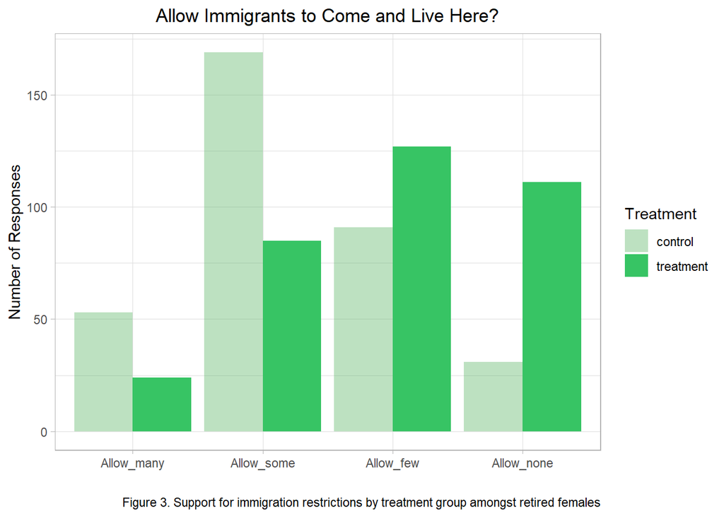

```r
#gather relevant variables
figure2_females1 <-data2[,c("alpfpne", "agea", "cntry",  "gndr", "rtrd")]
figure2_females2 <-data2[,c("allbpne", "agea", "cntry",  "gndr", "rtrd")]

#restricting to females aged 50-69
figure2_females1 <- figure2_females1 %>%
  filter( between(agea, 50, 69)) %>%
  filter(gndr == 2) %>%
  filter(rtrd == 1)

figure2_females2 <- figure2_females2 %>%
  filter( between(agea, 50, 69)) %>%
  filter(gndr == 2) %>%
  filter(rtrd == 1)

#restricting to the previously used 14 countries
figure2_females1 <- subset(figure2_females1, cntry %in% c("AT", "BE", "DK", "FI", "FR", "DE", "IE", "NL", "PT", "ES", "SE", "GB", "CH", "NO"))

figure2_females2 <- subset(figure2_females2, cntry %in% c("AT", "BE", "DK", "FI", "FR", "DE", "IE", "NL", "PT", "ES", "SE", "GB", "CH", "NO"))

#remove NAs
figure2_females1 <- na.omit(figure2_females1)
figure2_females2 <- na.omit(figure2_females2)

#rename columns
figure2_females1 <- rename(figure2_females1, c("alpfpne"="answer"))
figure2_females2 <- rename(figure2_females2, c("allbpne"="answer"))

#add treatment column
figure2_females1['Treatment']='control'
figure2_females2['Treatment']='treatment'

#new data frames for count
f1 <- setDT(figure2_females1)[,.(Allow_many=sum(answer==1)),
         by=Treatment]
f2 <- setDT(figure2_females1)[,.(Allow_some=sum(answer==2)),
         by=Treatment]
f3 <- setDT(figure2_females1)[,.(Allow_few=sum(answer==3)),
         by=Treatment]
f4 <- setDT(figure2_females1)[,.(Allow_none=sum(answer==4)),
         by=Treatment]

fem1 <- setDT(figure2_females2)[,.(Allow_many=sum(answer==1)),
         by=Treatment]
fem2 <- setDT(figure2_females2)[,.(Allow_some=sum(answer==2)),
         by=Treatment]
fem3 <- setDT(figure2_females2)[,.(Allow_few=sum(answer==3)),
         by=Treatment]
fem4 <- setDT(figure2_females2)[,.(Allow_none=sum(answer==4)),
         by=Treatment]


#merging data frames

#control group
f1$Allow_some <- f2$Allow_some
f1$Allow_few <- f3$Allow_few
f1$Allow_none <-f4$Allow_none

#treatment group
fem1$Allow_some <- fem2$Allow_some
fem1$Allow_few <- fem3$Allow_few
fem1$Allow_none <-fem4$Allow_none


#make long data frame

#control group
fg2_f <- f1%>%
  pivot_longer(
  cols = c(Allow_many, Allow_some, Allow_few, Allow_none),
  names_to = "Rating",
  values_to = "Number" )

#treatment group
fg2_f2 <- fem1%>%
  pivot_longer(
  cols = c(Allow_many, Allow_some, Allow_few, Allow_none),
  names_to = "Rating",
  values_to = "Number" )


#Combine the data frames vertically
females <- rbind(fg2_f, fg2_f2)


#plot graph
ggplot(females, aes(x = Rating,
                         y= Number,
                        fill = Treatment,
                        alpha = Treatment)) +
  geom_bar(stat = "identity",
           position = "dodge")+
  scale_x_discrete(limits = c("Allow_many",
                              "Allow_some",
                              "Allow_few",
                              "Allow_none"))+
  labs(x = "",
       y = "Number of Responses",
       fill = "Treatment",
       caption = " Figure 3. Support for immigration restrictions by treatment group amongst retired females")+
  scale_fill_manual(values = c("treatment" = "#37c464", "control" = "#59b365"))+
  theme_light()+
  ggtitle("Allow Immigrants to Come and Live Here?") +
  theme(plot.title = element_text(hjust = 0.5))+
  scale_alpha_discrete(range=c(0.4, 1.0))
```

The results for women were very similar to the results for men. There is a big difference when subjects are asked if professionals should be allowed in their country compared to unskilled laborers. This shows that, like men, women might think about the benefits and disadvantages of immigration in relation to their country’s economy. This is contrary to the labor market competition hypothesis, which states that people judge immigration based on its effect on their personal job prospects. This hypothesis is not supported by the OLS or IV models for either gender.

### References

```
1. Jeannet A-M. Revisiting the labor market competition hypothesis in a comparative perspective: Does retirement            affect opinion about immigration? Research & Politics. July 2018. doi:10.1177/2053168018784503

2. Ponce A. Gender and Anti-immigrant Attitudes in Europe. Socius. January 2017. doi:10.1177/2378023117729970

3. Hadley Wickham and Evan Miller (2020). haven: Import and Export 'SPSS', 'Stata' and 'SAS' Files. R package
version 2.3.1. https://CRAN.R-project.org/package=haven

4. Hadley Wickham (2020). tidyr: Tidy Messy Data. R package version 1.1.2.
https://CRAN.R-project.org/package=tidyr

5.  Hadley Wickham, Romain François, Lionel Henry and Kirill Müller (2021). dplyr: A Grammar of Data
Manipulation. R package version 1.0.4. https://CRAN.R-project.org/package=dplyr

6. H. Wickham. ggplot2: Elegant Graphics for Data Analysis. Springer-Verlag New York, 2016.

7. Malcolm Barrett (2021). ggdag: Analyze and Create Elegant Directed Acyclic Graphs. R package version 0.2.3.
https://CRAN.R-project.org/package=ggdag

8. Johannes Textor, Benito van der Zander, Mark K. Gilthorpe, Maciej Liskiewicz, George T.H. Ellison (2016).
Robust causal inference using directed acyclic graphs: the R package 'dagitty'. International Journal of
Epidemiology 45(6):1887-1894.

9. Yves Rosseel (2012). lavaan: An R Package for Structural Equation Modeling. Journal of Statistical Software,
48(2), 1-36. URL http://www.jstatsoft.org/v48/i02/.

10. David Robinson, Alex Hayes and Simon Couch (2021). broom: Convert Statistical Objects into Tidy Tibbles. R
package version 0.7.5. https://CRAN.R-project.org/package=broom

11. Sam Firke (2021). janitor: Simple Tools for Examining and Cleaning Dirty Data. R package version 2.1.0.
https://CRAN.R-project.org/package=janitor

12. Hlavac, Marek (2018). stargazer: Well-Formatted Regression and Summary Statistics Tables. R package version
5.2.1. https://CRAN.R-project.org/package=stargazer

13. Yihui Xie (2021). knitr: A General-Purpose Package for Dynamic Report Generation in R. R package version
1.31.

Yihui Xie (2015) Dynamic Documents with R and knitr. 2nd edition. Chapman and Hall/CRC. ISBN 978-1498716963

Yihui Xie (2014) knitr: A Comprehensive Tool for Reproducible Research in R. In Victoria Stodden, Friedrich
```

[output cut: 17 more lines]

```

19. Graeme Blair, Jasper Cooper, Alexander Coppock, Macartan Humphreys and Luke Sonnet (2021). estimatr: Fast
Estimators for Design-Based Inference. R package version 0.30.2. https://CRAN.R-project.org/package=estimatr

20. Lüdecke D (2021). _sjPlot: Data Visualization for Statistics in Social Science_. R package version 2.8.8, <URL:
https://CRAN.R-project.org/package=sjPlot>.

21. Jeffrey B. Arnold (2021). ggthemes: Extra Themes, Scales and Geoms for 'ggplot2'. R package version 4.2.4.
https://CRAN.R-project.org/package=ggthemes

22.  Hadley Wickham and Dana Seidel (2020). scales: Scale Functions for Visualization. R package version 1.1.1.
https://CRAN.R-project.org/package=scales

23.  Joe Cheng, Carson Sievert, Winston Chang, Yihui Xie and Jeff Allen (2021). htmltools: Tools for HTML. R package
version 0.5.1.1. https://CRAN.R-project.org/package=htmltools
```